# PCA Analysis

2023-03-10

[output not shown]

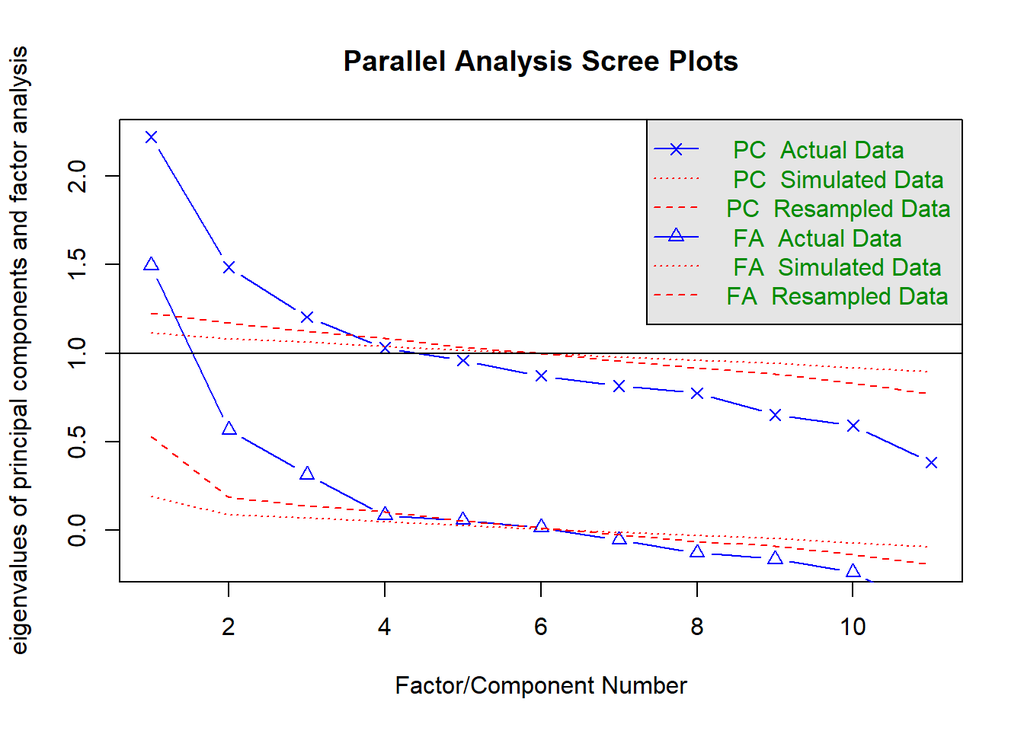

```
## Parallel analysis suggests that the number of factors =  5  and the number of components =  3
```

[output not shown]

[output not shown]

# PCA Analysis

We performed principal component analysis (PCA) on the funding preferences (kt_X variables). Each PC is a linear combination of the 11 kt_X variables. Based on Horn’s parallel analysis (1965), we selected the top 3 components as their Eigenvalues exceeded those from randomly generated data. We interpreted the pattern of loadings of each PC to assign a “name” for it:

| Item | senior | thematic | ecr |
| --- | --- | --- | --- |
| kt_personal_senior | 0.81 | 0.04 | 0.01 |
| kt_team | 0.56 | 0.38 | -0.03 |
| kt_personal_ecr | 0.30 | -0.05 | 0.53 |
| kt_thematic | 0.05 | 0.72 | -0.12 |
| kt_thematic_co | -0.07 | 0.65 | 0.14 |
| kt_small_first | -0.42 | -0.04 | 0.49 |
| kt_small_second | 0.12 | 0.10 | 0.48 |
| kt_award | 0.43 | -0.18 | 0.23 |
| kt_first_ecr | -0.14 | -0.32 | 0.49 |
| kt_rolling_ecr | -0.43 | -0.51 | -0.37 |
| kt_rolling_senior | 0.00 | -0.37 | -0.64 |

# Correlation analysis

For each PC, we calculated bivariate correlations with potential predictors:

| Variable | senior | thematic | ecr |
| --- | --- | --- | --- |
| versie | -0.0189149903069983 | 0.00958159178341183 | 0.0456292135690107 |
| age | 0.109221610374164 | -0.0315302393416414 | -0.218152350402354 |
| quit_ever | -0.0190242645323343 | -0.0228420392560569 | 0.0558520955546037 |
| major_changes | -0.141975059343569 | -0.198331401662117 | -0.0204088416530977 |
| applied_grant | 0.083275770559731 | -0.0522002603695124 | -0.143123805959745 |
| got_grant | 0.146171558239796 | -0.0433215342476132 | -0.147927707042787 |
| grant_no | -0.0651977696827052 | 0.0235584138183531 | 0.135114340889152 |
| grant_pers_nl | 0.0429514439954135 | -0.127826116758713 | -0.0751119912707026 |
| grant_pers_foreign | 0.104994832404366 | -0.139907348063209 | -0.101085233918594 |
| grant_consortium | 0.0452784206713298 | 0.0509453490137083 | -0.175545804281165 |

[output cut: 63 more lines]

# LASSO model

We also fitted LASSO-penalized regression models, which shrink small coefficients towards zero in order to select only relevant predictors of the PCs.

We used cross-validation to determine the optimum amount of shrinkage, selecting the largest shrinkage parameter $\lambda$ that was within 1SE of the $\lambda$ with the minimum cross-validated error. This is a commonly used criterion to retain the most parsimoneous model that still predicts the outcome well.

To assess overall model fit, we computed the cross-validated explained variance, $R^2_{cv}$, which can be interpreted as the percent reduction in the prediction error. We obtained the following $R^2_{cv}s$: for the `ecr` component, $R^2_{cv} = 0.20$; for the `senior` component, $R^2_{cv} = 0.27$; for the `thematic` component, $R^2_{cv} = 0.28$.

| pred | ecr |
| --- | --- |
| discipline.cHumanities.and.social.sciences | 0.192533840986168 |
| pos5 | -0.136737667106 |
| discipline.cBeta.and.medicine | -0.0811976113159553 |
| time_phds | -0.0667208162647165 |
| time_management_low | -0.0628616605031902 |
| who_committee | 0.0373589447125305 |
| age | -0.00937607538217516 |

| pred | senior |
| --- | --- |
| discipline.cBeta.and.medicine | 0.475829646649105 |
| award_fair | 0.162394907413951 |
| who_society | -0.115292702512094 |
| who_university | -0.052247542919709 |
| who_committee | 0.0510441125724017 |
| carreer_success | 0.0472744565792846 |
| rol_nwo | 0.0367434556960721 |
| got_grant | 0.0248219449154725 |
| co_irrelevant | 0.0139356338202069 |
| time_phds | 0.0135913983403155 |

[output cut: 3 more lines]

| pred | thematic |
| --- | --- |
| major_changes | -0.224417148984238 |
| who_society | 0.168871145304979 |
| co_private | -0.124916241831908 |
| grant_pers_nl | -0.120853310997926 |
| who_researcher | -0.112458288423801 |
| body_none | -0.107915031043546 |
| grant_pers_foreign | -0.091836286221321 |
| sex.cMan | -0.0587738287973767 |
| who_committee | 0.0508912957022549 |
| award_time | -0.0443127659405471 |

[output cut: 6 more lines]